# GGplot2 Extension

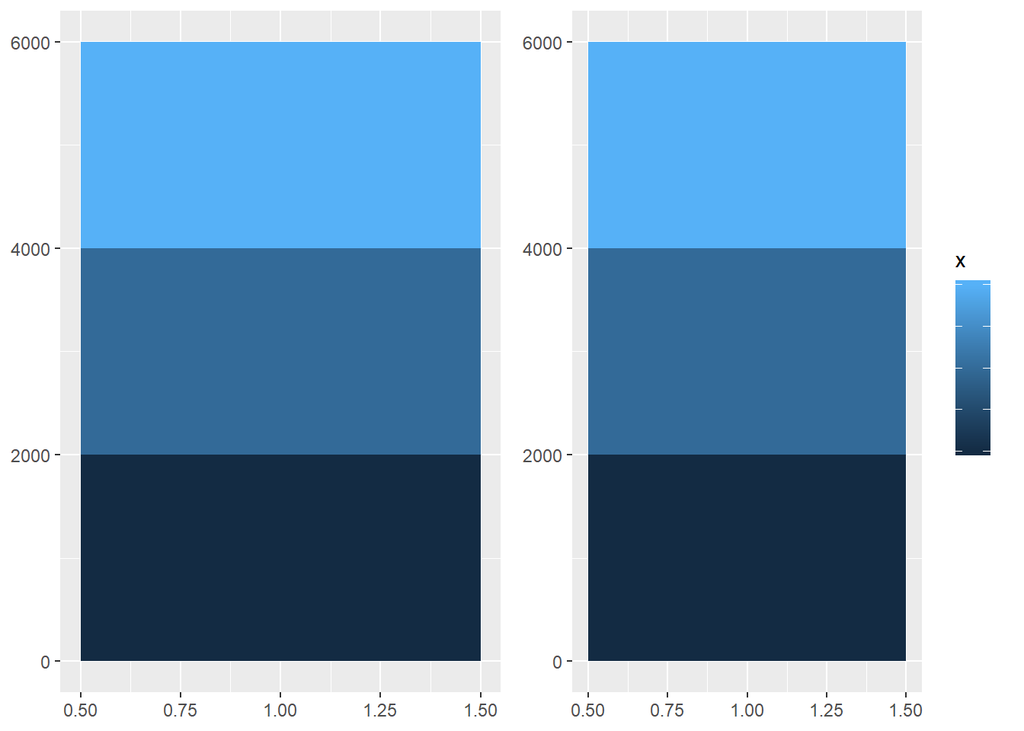

```r
g1<-leg + scale_fill_continuous(breaks = NULL)
g2<-leg + scale_fill_continuous(labels = NULL)

grid.arrange(g1,g2,ncol=2)
```

- Additionally, you can supply a function to breaks or labels. The breaks function should have one argument, the limits (a numeric vector of length two), and should return a numeric vector of breaks. The labels function should accept a numeric vector of breaks and return a character vector of labels (the same length as the input). The scales package provides a number of useful labelling functions:
1. scales::comma format() adds commas to make it easier to read large numbers.
2. scales::unit format(unit, scale) adds a unit suffix, optionally scaling.
3. scales::dollar format(prefix, suffix) displays currency values, rounding. to two decimal places and adding a prefix or suffix.
4. scales::wrap format() wraps long labels into multiple lines.
- See the documentation of the scales package for more details.

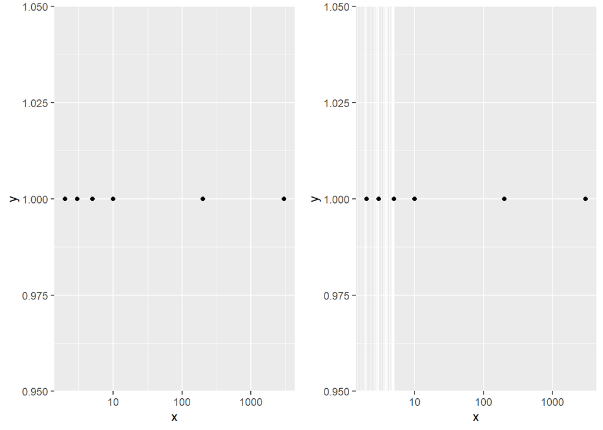

```r
library(ggplot2)
library(dplyr)
library(gridExtra)
library(mgcv)
library(MASS)
library(directlabels)

df <- data.frame(x = c(2, 3, 5, 10, 200, 3000), y = 1)

g1<-ggplot(df, aes(x, y)) +
geom_point() +
scale_x_log10()
mb <- as.numeric(1:10 %o% 10 ^ (0:4))

g2<-ggplot(df, aes(x, y)) +
geom_point() +
scale_x_log10(minor_breaks = log10(mb))

grid.arrange(g1,g2,ncol=2)
```

- You can adjust the minor breaks (the faint grid lines that appear between the major grid lines) by supplying a numeric vector of positions to the minor breaks argument. This is particularly useful for log scales:
- Note the use of %o% to quickly generate the multiplication table, and that the minor breaks must be supplied on the transformed scale.

## Legends

- While the most important parameters are shared between axes and legends, there are some extra options that only apply to legends. Legends are more complicated than axes because:
1. A legend can display multiple aesthetics (e.g. colour and shape), from multiple layers, and the symbol displayed in a legend varies based on the geom used in the layer.
2. Axes always appear in the same place. Legends can appear in different places, so you need some global way of controlling them.
3. Legends have considerably more details that can be tweaked: should they be displayed vertically or horizontally? How many columns? How big should the keys be?
- The following sections describe the options that control these interactions.

### Layers and Legends

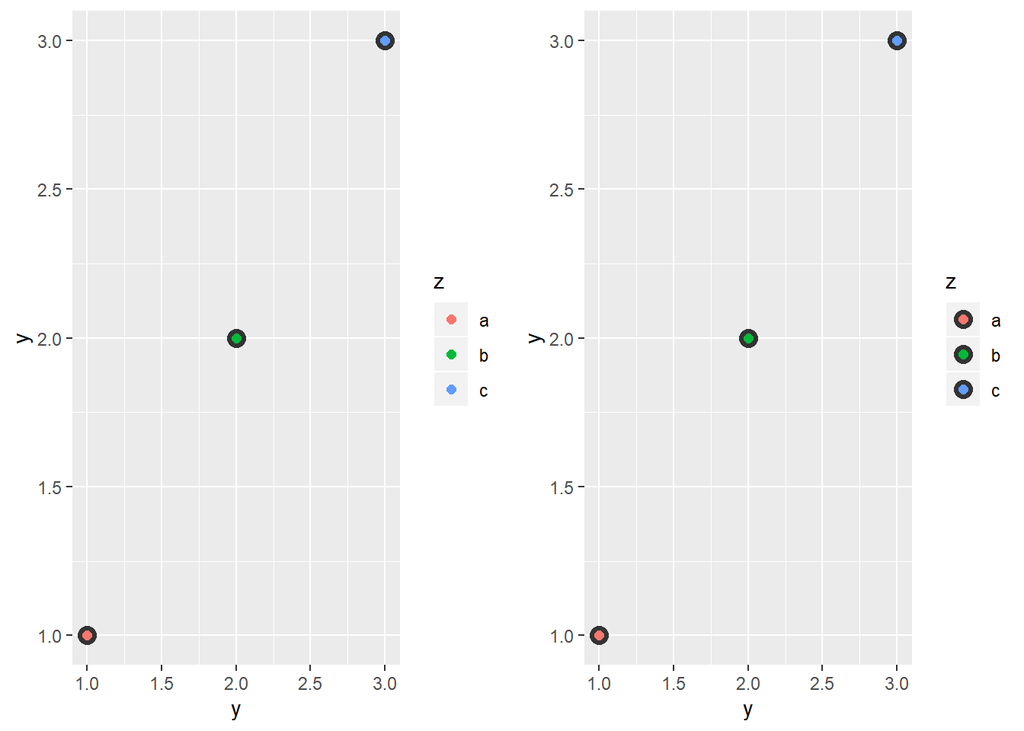

```r
library(ggplot2)
library(dplyr)
library(gridExtra)
library(mgcv)
library(MASS)
library(directlabels)

df <- data.frame(y = 1:3, y = 1:3, z = c("a","b","c"))

g1<-ggplot(df, aes(y, y)) +
geom_point(size = 4, colour = "grey20") +
geom_point(aes(colour = z), size = 2)

g2<-ggplot(df, aes(y, y)) +
geom_point(size = 4, colour = "grey20", show.legend = TRUE) +
geom_point(aes(colour = z), size = 2)

grid.arrange(g1,g2,ncol=2)
```

- Sometimes you want the geoms in the legend to display differently to the geoms in the plot. This is particularly useful when you’ve used transparency or size to deal with moderate overplotting and also used colour in the plot. You can do this using the override.aes parameter of guide legend(), which you’ll learn more about shortly.

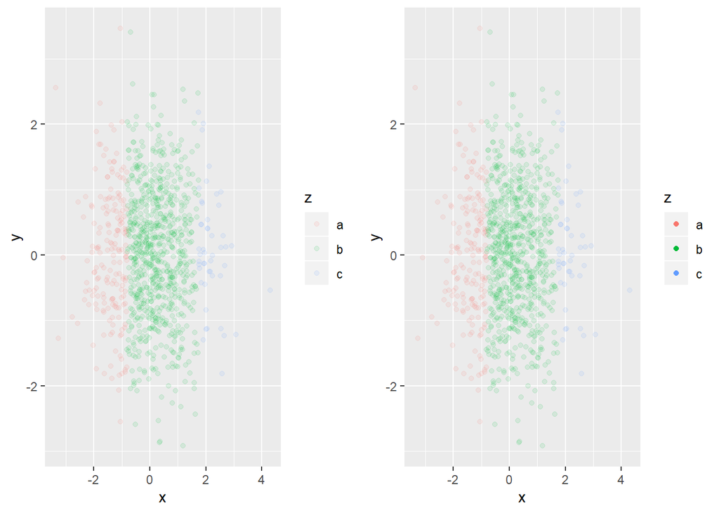

```r
library(ggplot2)
library(dplyr)
library(gridExtra)
library(mgcv)
library(MASS)
library(directlabels)

norm <- data.frame(x = rnorm(1000), y = rnorm(1000))
norm$z <- cut(norm$x, 3, labels = c("a", "b", "c"))

g1<-ggplot(norm, aes(x, y)) +
geom_point(aes(colour = z), alpha = 0.1)

g2<-ggplot(norm, aes(x, y)) +
geom_point(aes(colour = z), alpha = 0.1) +
guides(colour = guide_legend(override.aes = list(alpha = 1)))

grid.arrange(g1,g2,ncol=2)
```

### Legend Layout

- A number of settings that affect the overall display of the legends are controlled through the theme system. You’ll learn more about that in Sect. 8.2, but for now, all you need to know is that you modify theme settings with the theme() function.
- The position and justification of legends are controlled by the theme setting legend.position, which takes values “right”, “left”, “top”, “bottom”, or “none” (no legend).

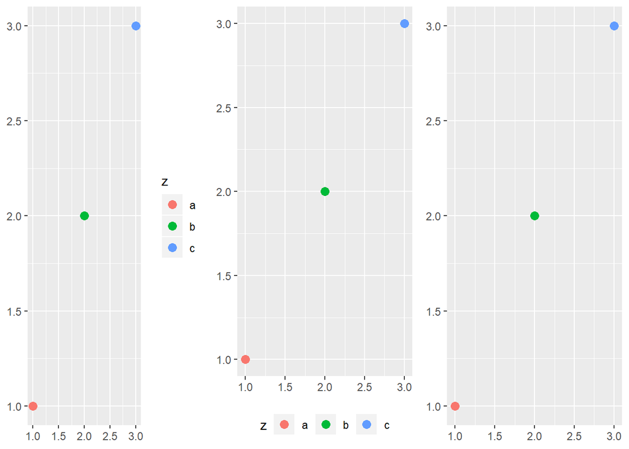

```r
library(ggplot2)
library(dplyr)
library(gridExtra)
library(mgcv)
library(MASS)
library(directlabels)

df <- data.frame(x = 1:3, y = 1:3, z = c("a", "b", "c"))
base <- ggplot(df, aes(x, y)) +
geom_point(aes(colour = z), size = 3) +
xlab(NULL) +
ylab(NULL)

g1<-base + theme(legend.position = "right") # the default
g2<-base + theme(legend.position = "bottom")
g3<-base + theme(legend.position = "none")

grid.arrange(g1,g2,g3,ncol=3)
```

- Switching between left/right and top/bottom modifies how the keys in each legend are laid out (horizontal or vertically), and how multiple legends are stacked (horizontal or vertically). If needed, you can adjust those options independently:
1. legend.direction: layout of items in legends (“horizontal” or “vertical”).
2. legend.box: arrangement of multiple legends (“horizontal” or “vertical”).
3. legend.box.just: justification of each legend within the overall bounding box, when there are multiple legends (“top”, “bottom”, “left”, or “right”).
- Alternatively, if there’s a lot of blank space in your plot you might want to place the legend inside the plot. You can do this by setting legend.position to a numeric vector of length two. The numbers represent a relative location in the panel area: c(0, 1) is the top-left corner and c(1, 0) is the bottom-right corner. You control which corner of the legend the legend.position refers to with legend.justification, which is specified in a similar way. Unfortunately positioning the legend exactly where you want it requires a lot of trial and error.

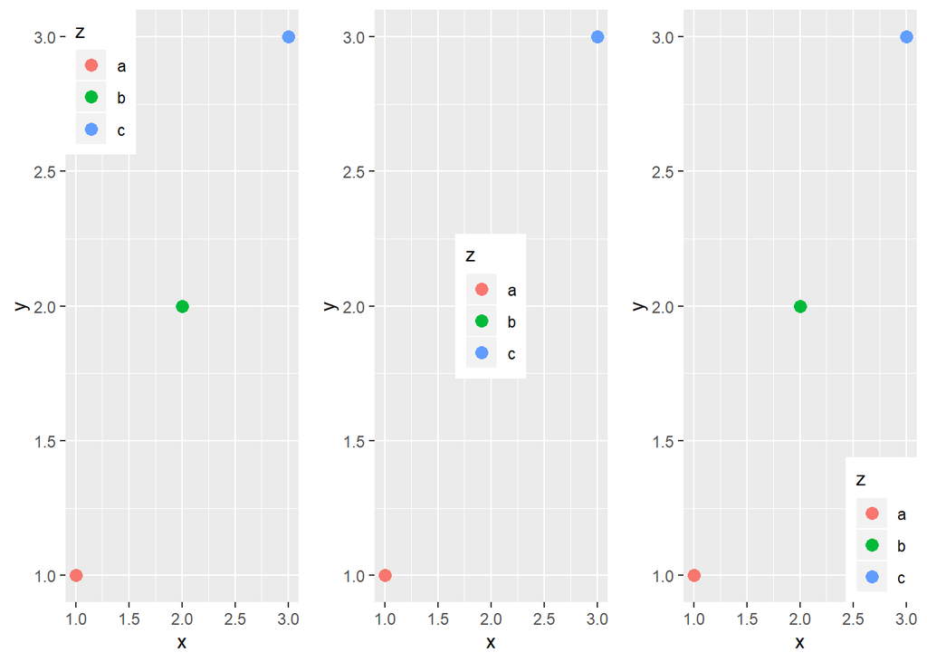

```r
library(ggplot2)
library(dplyr)
library(gridExtra)
library(mgcv)
library(MASS)
library(directlabels)

base <- ggplot(df, aes(x, y)) +
geom_point(aes(colour = z), size = 3)
g1<-base + theme(legend.position = c(0, 1), legend.justification = c(0, 1))
g2<-base + theme(legend.position = c(0.5, 0.5), legend.justification = c(0.5, 0.5))
g3<-base + theme(legend.position = c(1, 0), legend.justification = c(1, 0))

grid.arrange(g1,g2,g3,ncol=3)
```

- There’s also a margin around the legends, which you can suppress with legend.margin = unit(0, “mm”).

## Guide Functions

- The guide functions, guide colourbar() and guide legend(), offer additional control over the fine details of the legend. Legend guides can be used for any aesthetic (discrete or continuous) while the colour bar guide can only be used with continuous colour scales.
- You can override the default guide using the guide argument of the corresponding scale function, or more conveniently, the guides() helper function. guides() works like labs(): you can override the default guide associated with each aesthetic.

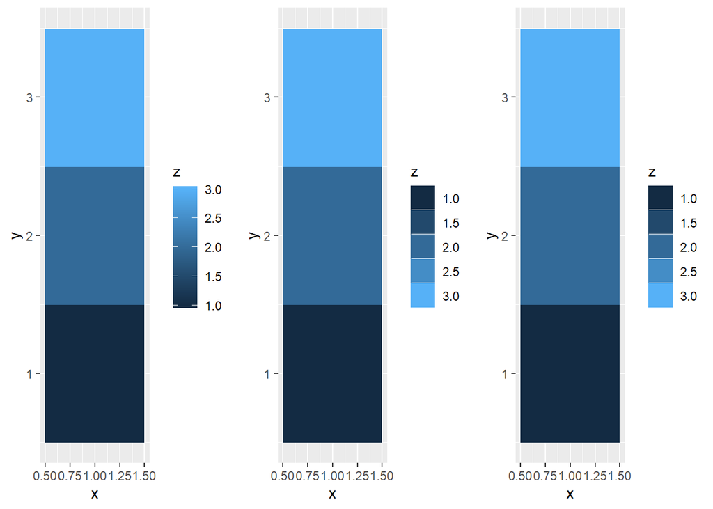

```r
library(ggplot2)
library(dplyr)
library(gridExtra)
library(mgcv)
library(MASS)
library(directlabels)

df <- data.frame(x = 1, y = 1:3, z = 1:3)
base <- ggplot(df, aes(x, y)) + geom_raster(aes(fill = z))
g1<-base
g2<-base + scale_fill_continuous(guide = guide_legend())
g3<-base + guides(fill = guide_legend())

grid.arrange(g1,g2,g3,ncol=3)
```

- Both functions have numerous examples in their documentation help pages that illustrate all of their arguments. Most of the arguments to the guide function control the fine level details of the text colour, size, font etc. You’ll learn about those in the themes chapter. Here I’ll focus on the most important arguments.

### guide legend()

- The legend guide displays individual keys in a table. The most useful options are:
1. nrow or ncol which specify the dimensions of the table. byrow controls how the table is filled: FALSE fills it by column (the default), TRUE fills it by row.

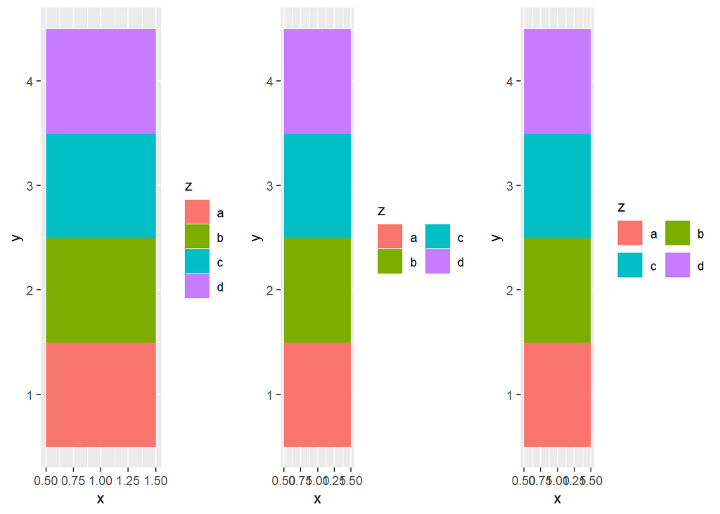

```r
library(ggplot2)
library(dplyr)
library(gridExtra)
library(mgcv)
library(MASS)
library(directlabels)

df <- data.frame(x = 1, y = 1:4, z = letters[1:4])
# Base plot
p <- ggplot(df, aes(x, y)) + geom_raster(aes(fill = z))
g1<-p
g2<-p + guides(fill = guide_legend(ncol = 2))
g3<-p + guides(fill = guide_legend(ncol = 2, byrow = TRUE))


grid.arrange(g1,g2,g3,ncol=3)
```

1. reverse reverses the order of the keys. This is particularly useful when you have stacked bars because the default stacking and legend orders are different:

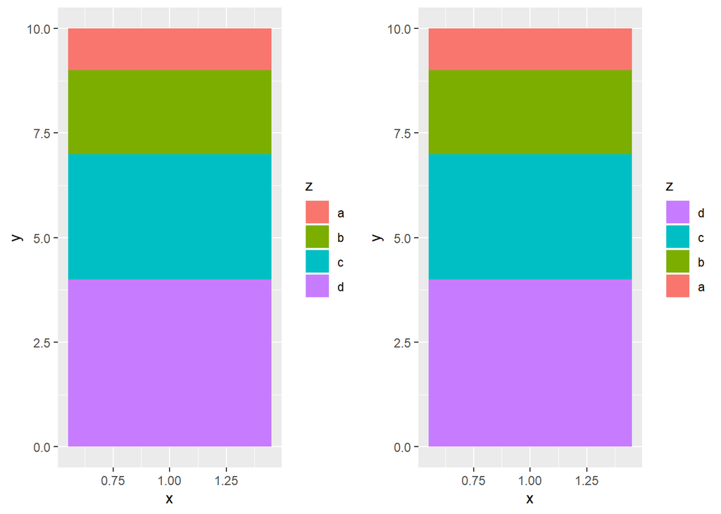

```r
library(ggplot2)
library(dplyr)
library(gridExtra)
library(mgcv)
library(MASS)
library(directlabels)

p <- ggplot(df, aes(1, y)) + geom_bar(stat = "identity", aes(fill = z))
g1<-p
g2<-p + guides(fill = guide_legend(reverse = TRUE))

grid.arrange(g1,g2,ncol=2)
```

1. override.aes: override some of the aesthetic settings derived from each layer. This is useful if you want to make the elements in the legend more visually prominent. See discussion in Sect. 6.4.1.
2. keywidth and keyheight (along with default.unit) allow you to specify the size of the keys. These are grid units, e.g. unit(1, “cm”).

## guide colourbar

- The colour bar guide is designed for continuous ranges of colors—as its name implies, it outputs a rectangle over which the color gradient varies. The most important arguments are:
1. barwidth and barheight (along with default.unit) allow you to specify the size of the bar. These are grid units, e.g. unit(1, “cm”).
2. nbin controls the number of slices. You may want to increase this from the default value of 20 if you draw a very long bar.
3. reverse flips the colour bar to put the lowest values at the top. These options are illustrated below:

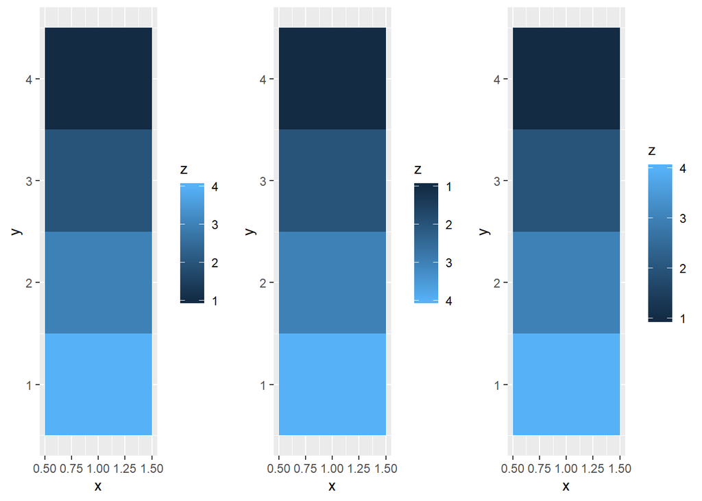

```r
library(ggplot2)
library(dplyr)
library(gridExtra)
library(mgcv)
library(MASS)
library(directlabels)

df <- data.frame(x = 1, y = 1:4, z = 4:1)
p <- ggplot(df, aes(x, y)) + geom_tile(aes(fill = z))
g1<-p
g2<-p + guides(fill = guide_colorbar(reverse = TRUE))
g3<-p + guides(fill = guide_colorbar(barheight = unit(4, "cm")))

grid.arrange(g1,g2,g3,ncol=3)
```

## Limits

- The limits, or domain, of a scale are usually derived from the range of the data. There are two reasons you might want to specify limits rather than relying on the data:
1. You want to make limits smaller than the range of the data to focus on an interesting area of the plot.
2. You want to make the limits larger than the range of the data because you want multiple plots to match up.
- It’s most natural to think about the limits of position scales: they map directly to the ranges of the axes. But limits also apply to scales that have legends, like colour, size, and shape. This is particularly important to realise if you want your colours to match up across multiple plots in your paper.
- You can modify the limits using the limits parameter of the scale:
1. For continuous scales, this should be a numeric vector of length two. If you only want to set the upper or lower limit, you can set the other value to NA.
2. For discrete scales, this is a character vector which enumerates all possible values.

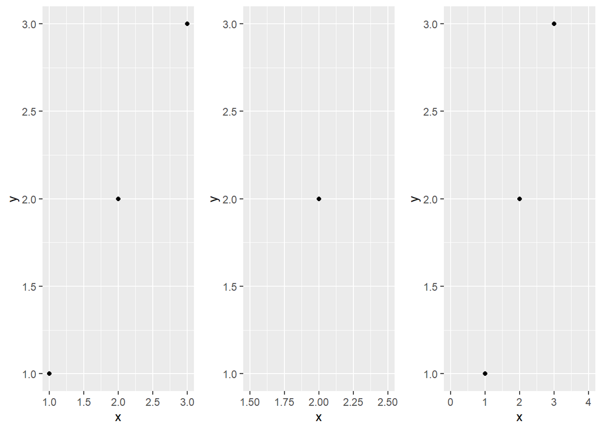

```r
library(ggplot2)
library(dplyr)
library(gridExtra)
library(mgcv)
library(MASS)
library(directlabels)

df <- data.frame(x = 1:3, y = 1:3)
base <- ggplot(df, aes(x, y)) + geom_point()
g1<-base
g2<-base + scale_x_continuous(limits = c(1.5, 2.5))
g3<-base + scale_x_continuous(limits = c(0, 4))

grid.arrange(g1,g2,g3,ncol=3)
```

- Because modifying the limits is such a common task, ggplot2 provides some helper to make this even easier: xlim(), ylim() and lims() These functions inspect their input and then create the appropriate scale, as follows:
1. xlim(10, 20): a continuous scale from 10 to 20.
2. ylim(20, 10): a reversed continuous scale from 20 to 10.
3. xlim(“a”, “b”, “c”): a discrete scale.
4. xlim(as.Date(c(“2008-05-01”, “2008-08-01”))): a date scale fromMay 1 to August 1 2008.

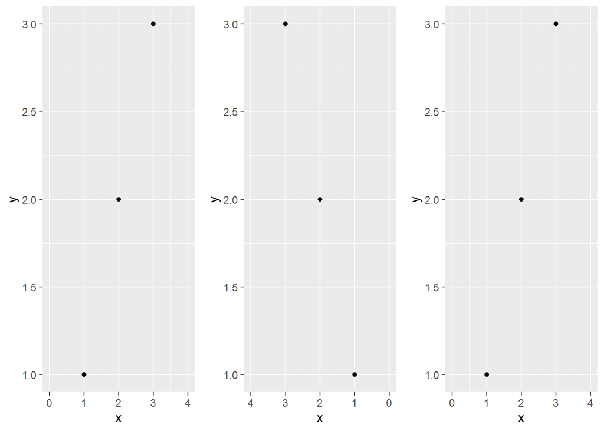

```r
library(ggplot2)
library(dplyr)
library(gridExtra)
library(mgcv)
library(MASS)
library(directlabels)

g1<-base + xlim(0, 4)
g2<-base + xlim(4, 0)
g3<-base + lims(x = c(0, 4))

grid.arrange(g1,g2,g3,ncol=3)
```

- If you have eagle eyes, you’ll have noticed that the range of the axes actually extends a little bit past the limits that you’ve specified. This ensures that the data does not overlap the axes. To eliminate this space, set expand = c(0, 0). This is useful in conjunction with geom raster():

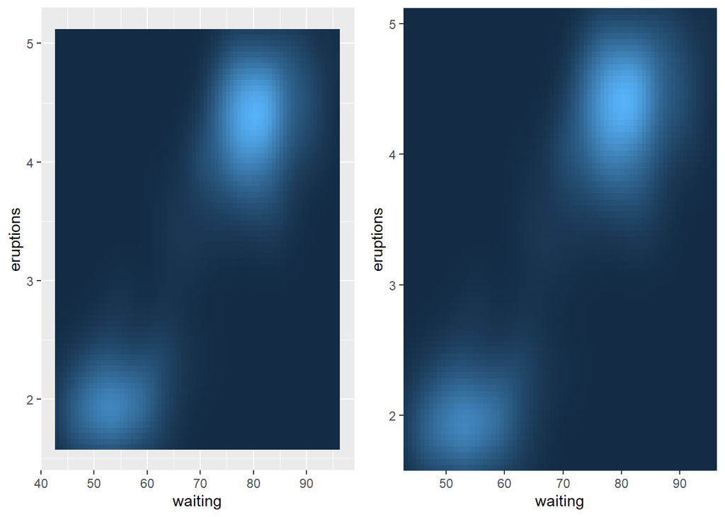

```r
library(ggplot2)
library(dplyr)
library(gridExtra)
library(mgcv)
library(MASS)
library(directlabels)

g1<-ggplot(faithfuld, aes(waiting, eruptions)) +
geom_raster(aes(fill = density)) +
theme(legend.position = "none")

g2<-ggplot(faithfuld, aes(waiting, eruptions)) +
geom_raster(aes(fill = density)) +
scale_x_continuous(expand = c(0,0)) +
scale_y_continuous(expand = c(0,0)) +
theme(legend.position = "none")

grid.arrange(g1,g2,ncol=2)
```

- By default, any data outside the limits is converted to NA. This means that setting the limits is not the same as visually zooming in to a region of the plot. To do that, you need to use the xlim and ylim arguments to coord cartesian(), described in Sect. 7.4. This performs purely visual zooming and does not affect the underlying data. You can override this with the oob (out of bounds) argument to the scale. The default is scales::censor() which replaces any value outside the limits with NA. Another option is scales::squish() which squishes all values into the range:

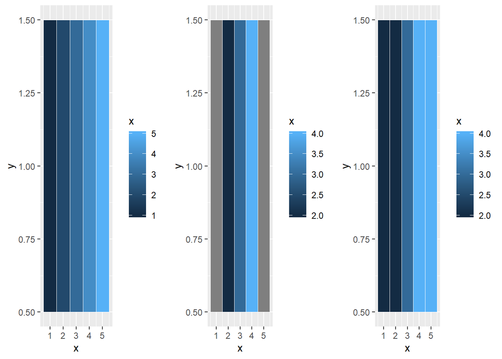

```r
library(ggplot2)
library(dplyr)
library(gridExtra)
library(mgcv)
library(MASS)
library(directlabels)

df <- data.frame(x = 1:5)
p <- ggplot(df, aes(x, 1)) + geom_tile(aes(fill = x), colour = "white")
g1<-p
g2<-p + scale_fill_gradient(limits = c(2, 4))
g3<-p + scale_fill_gradient(limits = c(2, 4), oob = scales::squish)

grid.arrange(g1,g2,g3,ncol=3)
```

## Scales Toolbox

- As well as tweaking the options of the default scales, you can also override them completely with new scales. Scales can be divided roughly into four families:
1. Continuous position scales used to map integer, numeric, and date/time data to x and y position.
2. Colour scales, used to map continuous and discrete data to colours.
3. Manual scales, used to map discrete variables to your choice of size, line type, shape or colour.
4. The identity scale, paradoxically used to plot variables without scaling them. This is useful if your data is already a vector of colour names.
- The follow sections describe each family in more detail.

## Continuous Position Scales

- Every plot has two position scales, x and y. The most common continuous position scales are scale x continuous() and scale y continuous(), which linearly map data to the x and y axis. The most interesting variations are produced using transformations. Every continuous scale takes a trans argument, allowing the use of a variety of transformations:

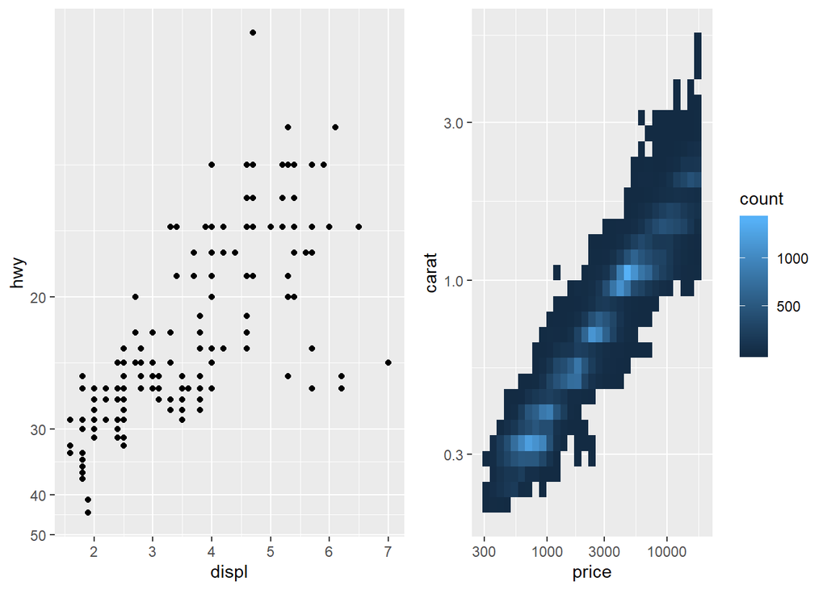

```r
library(ggplot2)
library(dplyr)
library(gridExtra)
library(mgcv)
library(MASS)
library(directlabels)

# Convert from fuel economy to fuel consumption
g1<-ggplot(mpg, aes(displ, hwy)) +
geom_point() +
scale_y_continuous(trans = "reciprocal")

# Log transform x and y axes
g2<-ggplot(diamonds, aes(price, carat)) +
geom_bin2d() +
scale_x_continuous(trans = "log10") +
scale_y_continuous(trans = "log10")

grid.arrange(g1,g2,ncol=2)
```

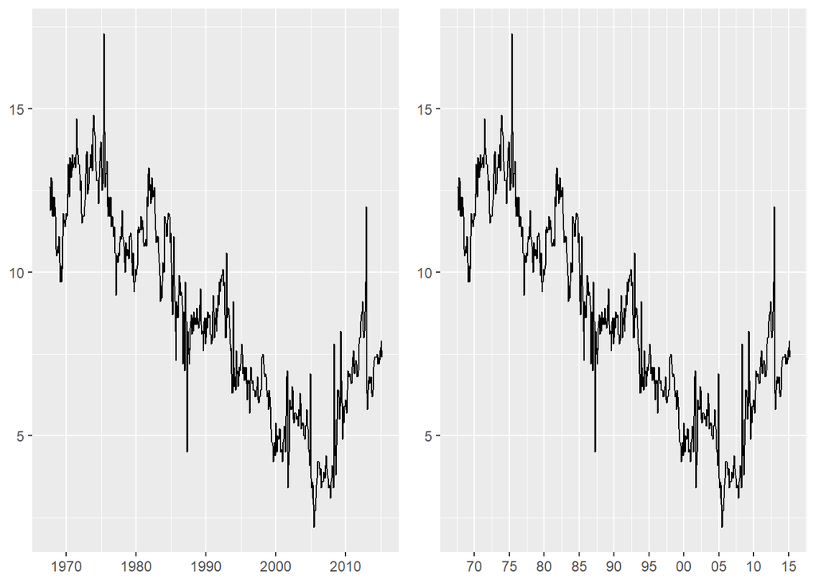

```r
library(ggplot2)
library(dplyr)
library(gridExtra)
library(mgcv)
library(MASS)
library(directlabels)

base <- ggplot(economics, aes(date, psavert)) +
geom_line(na.rm = TRUE) +
labs(x = NULL, y = NULL)

g1<-base # Default breaks and labels

g2<-base + scale_x_date(date_labels = "%y", date_breaks = "5 years")

grid.arrange(g1,g2,ncol=2)
```

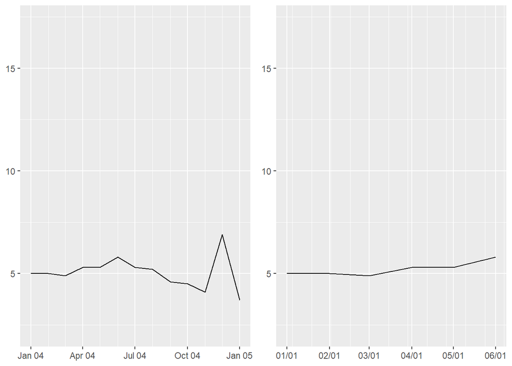

```r
library(ggplot2)
library(dplyr)
library(gridExtra)
library(mgcv)
library(MASS)
library(directlabels)

g1<-base + scale_x_date(
limits = as.Date(c("2004-01-01", "2005-01-01")),
date_labels = "%b %y",
date_minor_breaks = "1 month"
)

g2<-base + scale_x_date(
limits = as.Date(c("2004-01-01", "2004-06-01")),
date_labels = "%m/%d",
date_minor_breaks = "2 weeks"
)

grid.arrange(g1,g2,ncol=2)
```


## Continuous

- Colour gradients are often used to show the height of a 2d surface. In the following example we’ll use the surface of a 2d density estimate of the faithful dataset (Azzalini and Bowman, 1990), which records the waiting time between eruptions and during each eruption for the Old Faithful geyser in Yellowstone Park. I hide the legends and set expand to 0, to focus on the appearance of the data. . Remember: I’m illustrating these scales with filled tiles, but you can also use them with coloured lines and points.

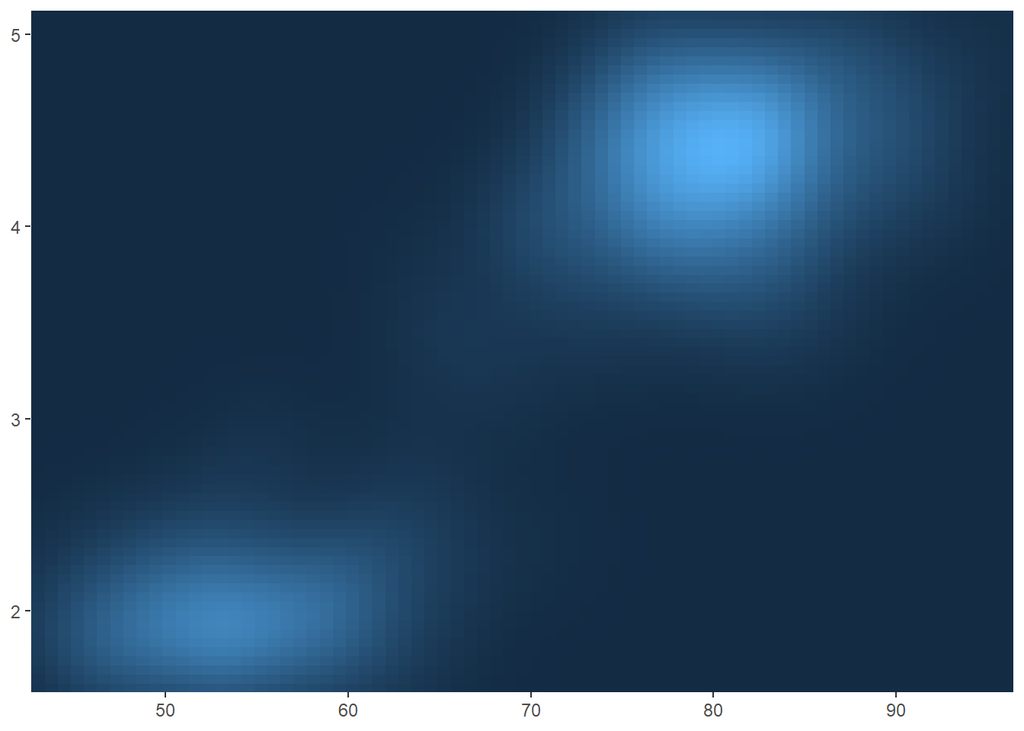

```r
library(ggplot2)
library(dplyr)
library(gridExtra)
library(mgcv)
library(MASS)
library(directlabels)

erupt <- ggplot(faithfuld, aes(waiting, eruptions, fill = density)) +
geom_raster() +
scale_x_continuous(NULL, expand = c(0, 0)) +
scale_y_continuous(NULL, expand = c(0, 0)) +
theme(legend.position = "none")
erupt
```

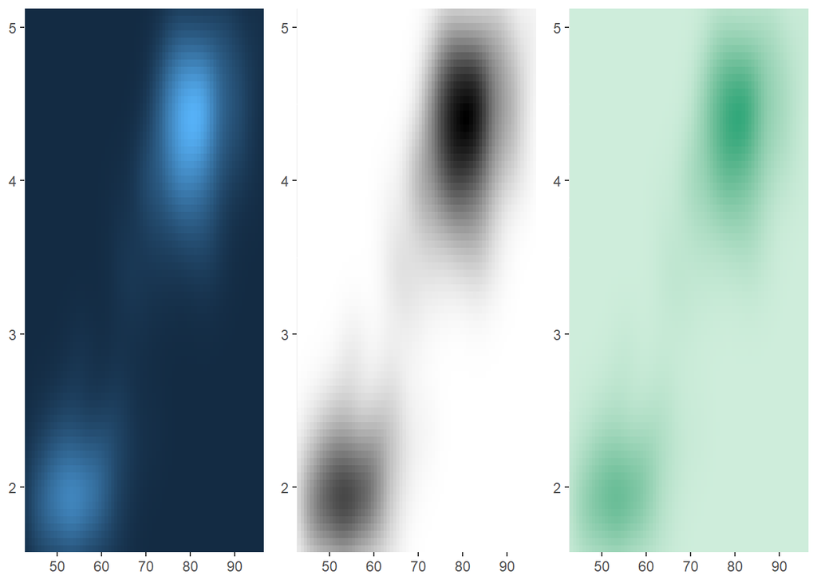

```r
library(ggplot2)
library(dplyr)
library(gridExtra)
library(mgcv)
library(MASS)
library(directlabels)

g1<-erupt
g2<-erupt + scale_fill_gradient(low = "white", high = "black")
g3<-erupt + scale_fill_gradient(
low = munsell::mnsl("5G 9/2"),
high = munsell::mnsl("5G 6/8")
)

grid.arrange(g1,g2,g3,ncol=3)
```

2. • scale colour gradient2() and scale fill gradient2(): a three-colour gradient, low-med-high (red-white-blue). As well as low and high colours, these scales also have a mid colour for the colour of the midpoint. The midpoint defaults to 0, but can be set to any value with the midpoint argument. It’s artificial to use this colour scale with this dataset, but we can force it by using the median of the density as the midpoint. Note that the blues are much more intense than the reds (which you only see as a very pale pink).

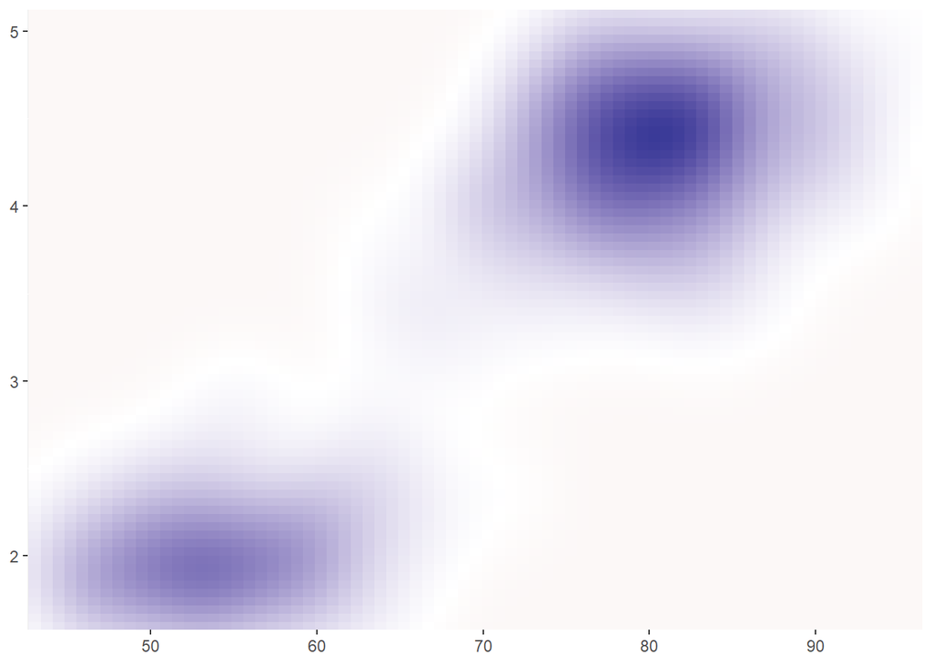

```r
library(ggplot2)
library(dplyr)
library(gridExtra)
library(mgcv)
library(MASS)
library(directlabels)

mid <- median(faithfuld$density)
erupt + scale_fill_gradient2(midpoint = mid)
```

3. scale colour gradientn() and scale fill gradientn(): a custom n-colour gradient. This is useful if you have colours that are meaningful for your data (e.g., black body colours or standard terrain colours), or you’d like to use a palette produced by another package. The following code includes palettes generated from routines in the colorspace package. (Zeileis et al.,2008) describes the philosophy behind these palettes and provides a good introduction to some of the complexities of creating good colour scales.

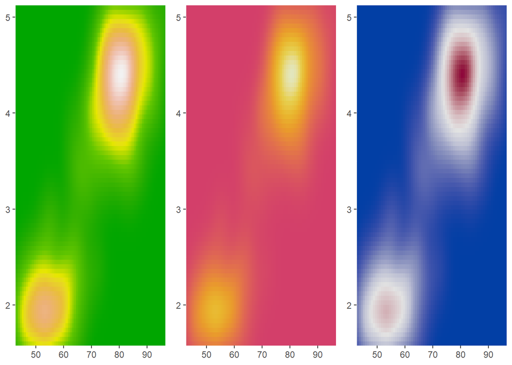

```r
library(ggplot2)
library(dplyr)
library(gridExtra)
library(mgcv)
library(MASS)
library(directlabels)

g1<-erupt + scale_fill_gradientn(colours = terrain.colors(7))
g2<-erupt + scale_fill_gradientn(colours = colorspace::heat_hcl(7))
g3<-erupt + scale_fill_gradientn(colours = colorspace::diverge_hcl(7))

grid.arrange(g1,g2,g3,ncol=3)
```

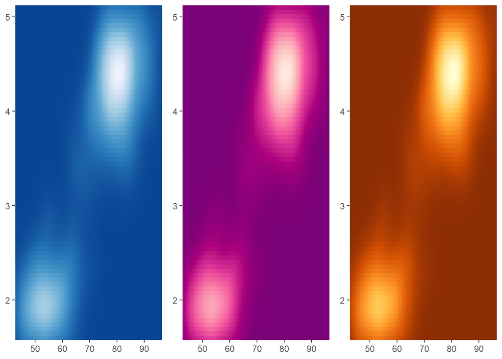

```r
library(ggplot2)
library(dplyr)
library(gridExtra)
library(mgcv)
library(MASS)
library(directlabels)

g1<-erupt + scale_fill_distiller()
g2<-erupt + scale_fill_distiller(palette = "RdPu")
g3<-erupt + scale_fill_distiller(palette = "YlOrBr")

grid.arrange(g1,g2,g3,ncol=3)
```

- All continuous colour scales have an na.value parameter that controls what colour is used for missing values (including values outside the range of the scale limits). By default it is set to grey, which will stand out when you use a colourful scale. If you use a black and white scale, you might want to set it to something else to make it more obvious.

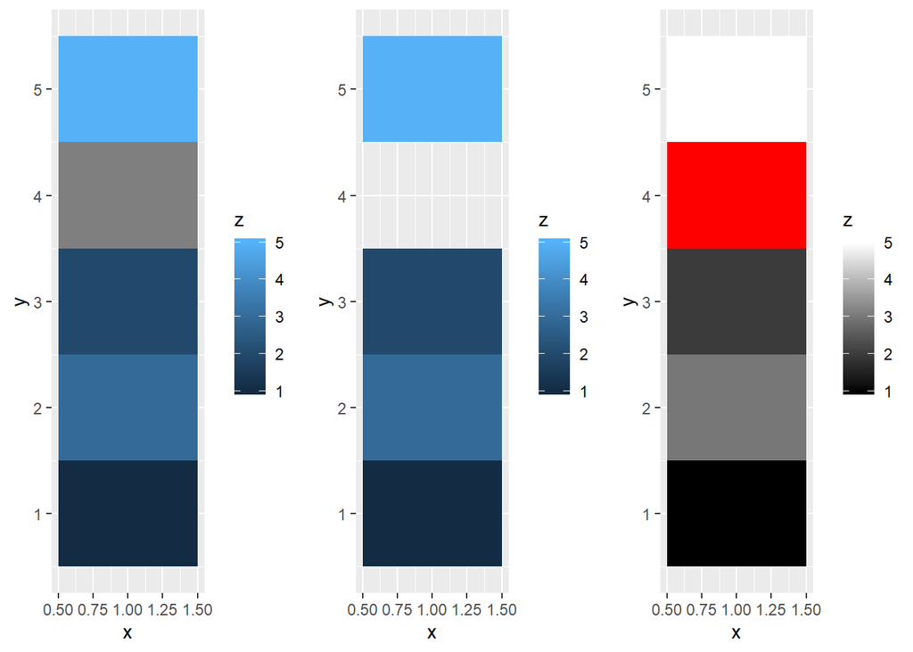

```r
library(ggplot2)
library(dplyr)
library(gridExtra)
library(mgcv)
library(MASS)
library(directlabels)

df <- data.frame(x = 1, y = 1:5, z = c(1, 3, 2, NA, 5))
p <- ggplot(df, aes(x, y)) + geom_tile(aes(fill = z), size = 5)
g1<-p
# Make missing colours invisible
g2<-p + scale_fill_gradient(na.value = NA)
# Customise on a black and white scale
g3<-p + scale_fill_gradient(low = "black", high = "white", na.value = "red")

grid.arrange(g1,g2,g3,ncol=3)
```

## Discrete

- There are four colour scales for discrete data. We illustrate them with a barchart that encodes both position and fill to the same variable:

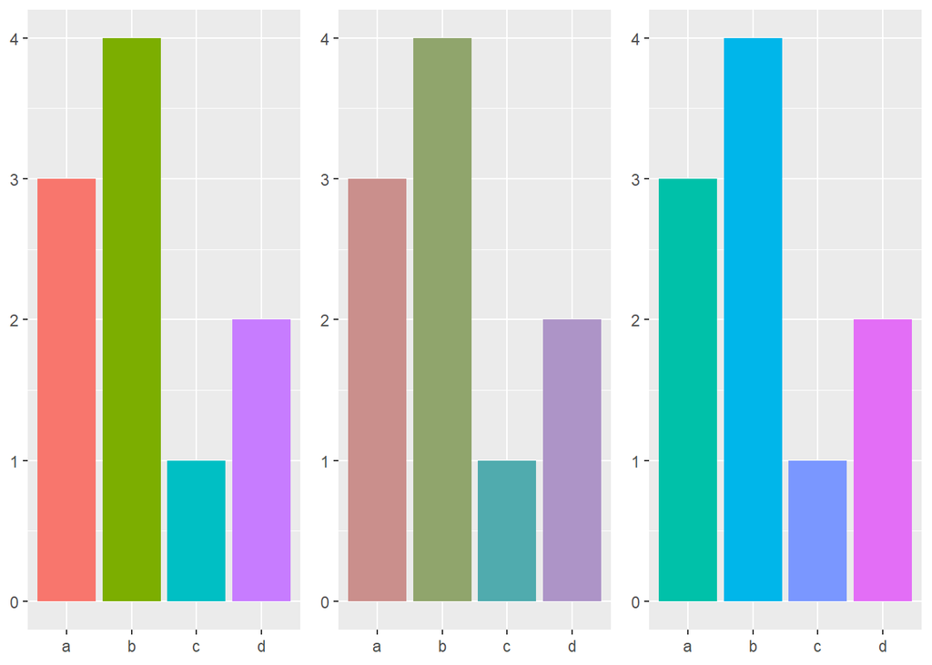

```r
library(ggplot2)
library(dplyr)
library(gridExtra)
library(mgcv)
library(MASS)
library(directlabels)

df <- data.frame(x = c("a", "b", "c", "d"), y = c(3, 4, 1, 2))
bars <- ggplot(df, aes(x, y, fill = x)) +
geom_bar(stat = "identity") +
labs(x = NULL, y = NULL) +
theme(legend.position = "none")

g1<-bars
g2<-bars + scale_fill_hue(c = 40)
g3<-bars + scale_fill_hue(h = c(180, 300))

grid.arrange(g1,g2,g3,ncol=3)
```

1. The default colour scheme, scale colour hue(), picks evenly spaced hues around the HCL colour wheel. This works well for up to about eight colours, but after that it becomes hard to tell the different colours apart. You can control the default chroma and luminance, and the range of hues, with the h, c and l arguments:
- One disadvantage of the default colour scheme is that because the colours all have the same luminance and chroma, when you print them in black and white, they all appear as an identical shade of grey.
2. scale colour brewer() uses handpicked “ColorBrewer” colours, http:// colorbrewer2.org/. These colours have been designed to work well in a wide variety of situations, although the focus is on maps and so the colours tend to work better when displayed in large areas. For categorical data, the palettes most of interest are ‘Set1’ and ‘Dark2’ for points and ‘Set2’, ‘Pastel1’, ‘Pastel2’ and ‘Accent’ for areas. Use RColorBrewer::display.brewer.all() to list all palettes.

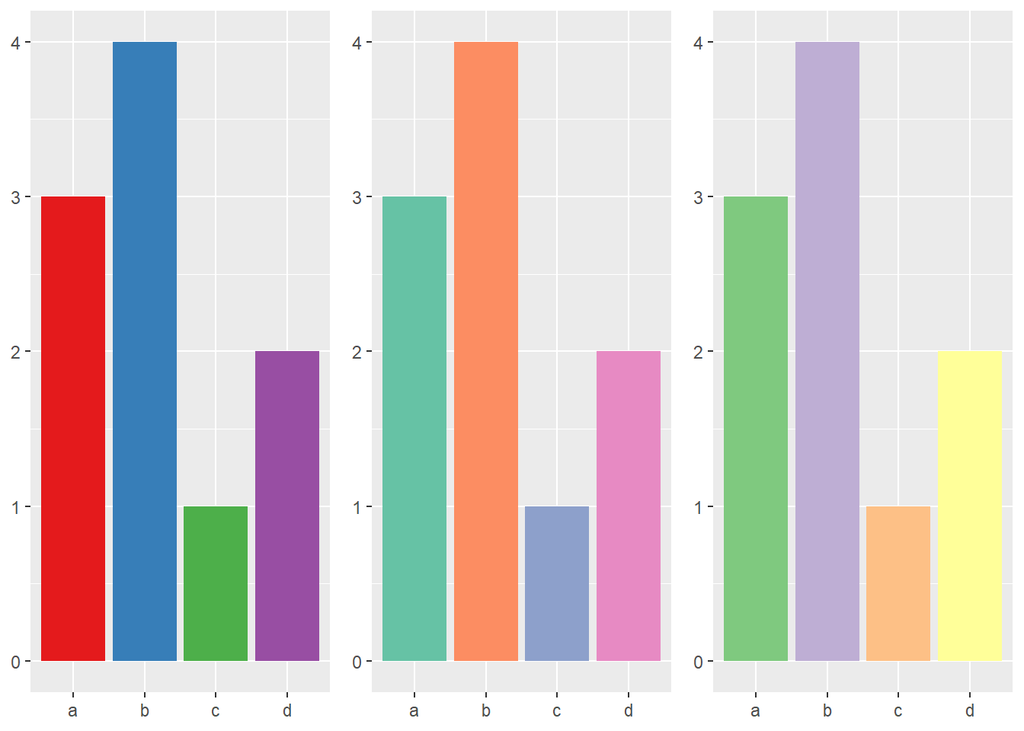

```r
library(ggplot2)
library(dplyr)
library(gridExtra)
library(mgcv)
library(MASS)
library(directlabels)

g1<-bars + scale_fill_brewer(palette = "Set1")
g2<-bars + scale_fill_brewer(palette = "Set2")
g3<-bars + scale_fill_brewer(palette = "Accent")

grid.arrange(g1,g2,g3,ncol=3)
```

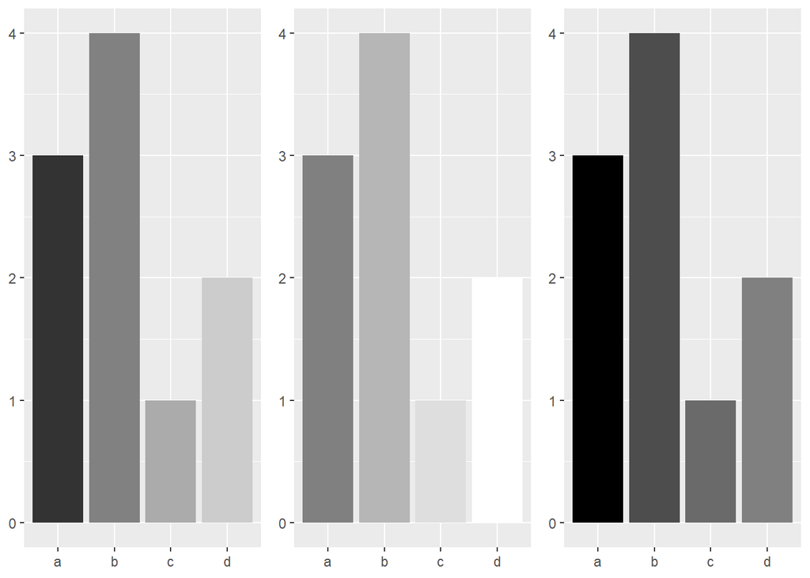

```r
library(ggplot2)
library(dplyr)
library(gridExtra)
library(mgcv)
library(MASS)
library(directlabels)

g1<-bars + scale_fill_grey()
g2<-bars + scale_fill_grey(start = 0.5, end = 1)
g3<-bars + scale_fill_grey(start = 0, end = 0.5)

grid.arrange(g1,g2,g3,ncol=3)
```

4. scale colour manual() is useful if you have your own discrete colour palette. The following examples show colour palettes inspired by Wes Anderson movies, as provided by the wesanderson package, https://github.com/karthik/wesanderson. These are not designed for perceptual uniformity, but are fun!

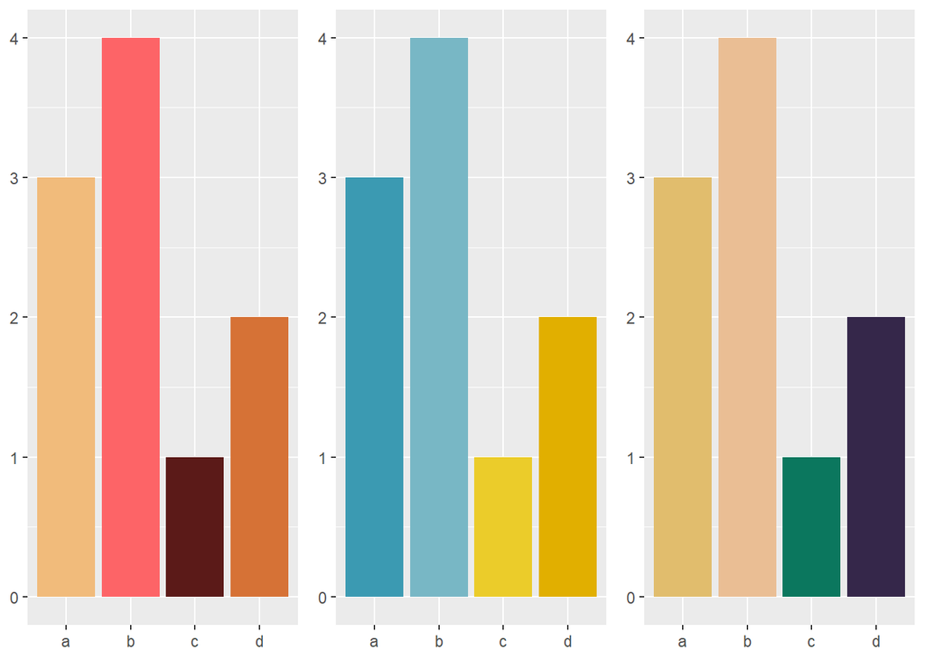

```r
library(ggplot2)
library(dplyr)
library(gridExtra)
library(mgcv)
library(MASS)
library(directlabels)
library(wesanderson)

g1<-bars + scale_fill_manual(values = wes_palette("GrandBudapest1"))
g2<-bars + scale_fill_manual(values = wes_palette("Zissou1"))
g3<-bars + scale_fill_manual(values = wes_palette("Rushmore1"))

grid.arrange(g1,g2,g3,ncol=3)
```

- Note that one set of colours is not uniformly good for all purposes: bright colours work well for points, but are overwhelming on bars. Subtle colours work well for bars, but are hard to see on points:

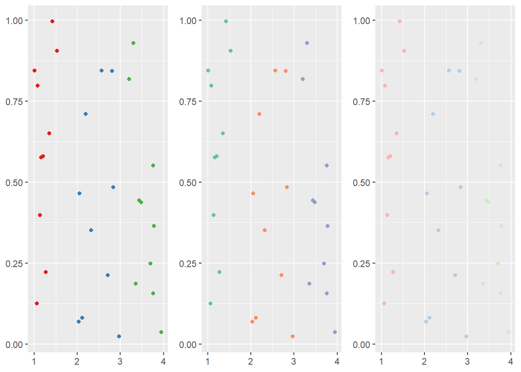

```r
library(ggplot2)
library(dplyr)
library(gridExtra)
library(mgcv)
library(MASS)
library(directlabels)
library(wesanderson)

# Bright colours work best with points
df <- data.frame(x = 1:3 + runif(30), y = runif(30), z = c("a", "b", "c"))
point <- ggplot(df, aes(x, y)) +
geom_point(aes(colour = z)) +
theme(legend.position = "none") +
labs(x = NULL, y = NULL)
g1<-point + scale_colour_brewer(palette = "Set1")
g2<-point + scale_colour_brewer(palette = "Set2")
g3<-point + scale_colour_brewer(palette = "Pastel1")

grid.arrange(g1,g2,g3,ncol=3)
```

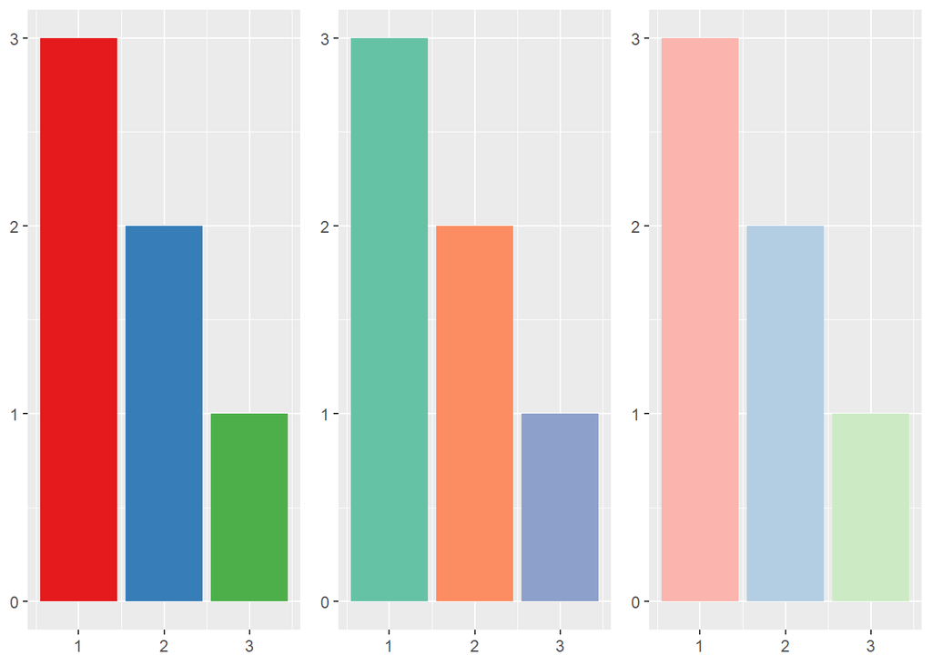

```r
library(ggplot2)
library(dplyr)
library(gridExtra)
library(mgcv)
library(MASS)
library(directlabels)
library(wesanderson)

# Subtler colours work better with areas
df <- data.frame(x = 1:3, y = 3:1, z = c("a", "b", "c"))
area <- ggplot(df, aes(x, y)) +
geom_bar(aes(fill = z), stat = "identity") +
theme(legend.position = "none") +
labs(x = NULL, y = NULL)
g1<-area + scale_fill_brewer(palette = "Set1")
g2<-area + scale_fill_brewer(palette = "Set2")
g3<-area + scale_fill_brewer(palette = "Pastel1")

grid.arrange(g1,g2,g3,ncol=3)
```

## The Manual Discrete Scale

- The discrete scales, scale linetype(), scale shape(), and scale size discrete() basically have no options. These scales are just a list of valid values that are mapped to the unique discrete values.
- If you want to customise these scales, you need to create your own new scale with the manual scale: scale shape manual(), scale linetype manual(),scale colour manual(). The manual scale has one important argument, values, where you specify the values that the scale should produce. If this vector is named, it will match the values of the output to the values of the input; otherwise it will match in order of the levels of the discrete variable. You will need some knowledge of the valid aesthetic values, which are described in vignette(“ggplot2-specs”).
- The following code demonstrates the use of scale colour manual():

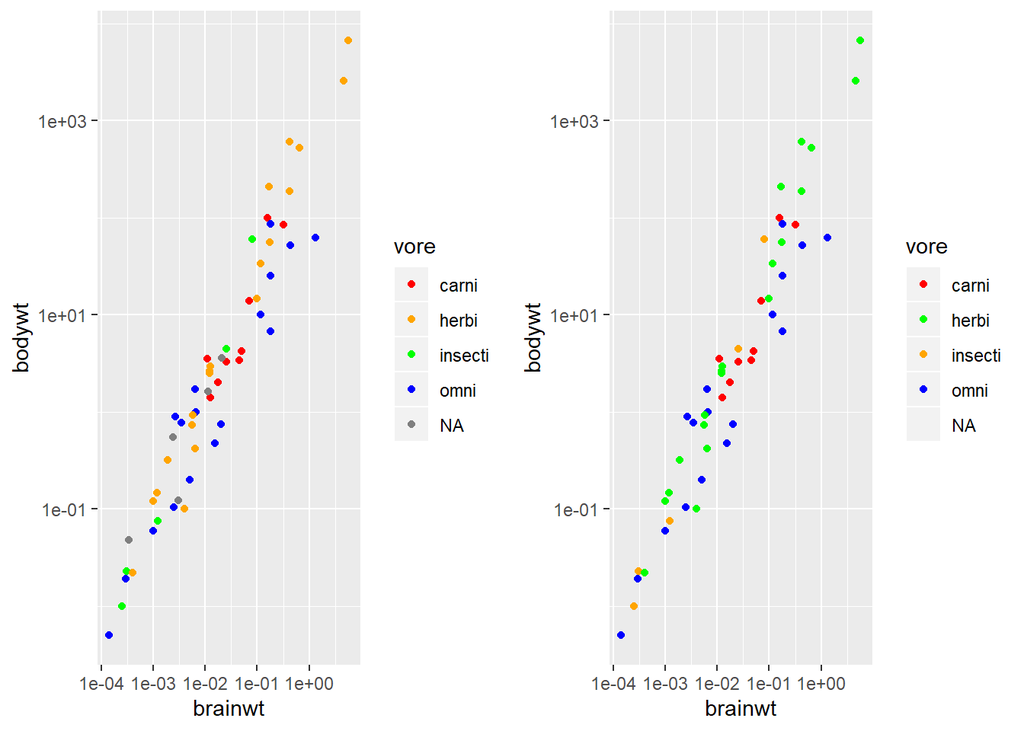

```r
library(ggplot2)
library(dplyr)
library(gridExtra)
library(mgcv)
library(MASS)
library(directlabels)
library(wesanderson)

plot <- ggplot(msleep, aes(brainwt, bodywt)) +
scale_x_log10() +
scale_y_log10()
g1<-plot +
geom_point(aes(colour = vore)) +
scale_colour_manual(
values = c("red", "orange", "green", "blue"),
na.value = "grey50"
)

colours <- c(
carni = "red",
insecti = "orange",
herbi = "green",
omni = "blue"
)

g2<-plot +
geom_point(aes(colour = vore)) +
scale_colour_manual(values = colours)


grid.arrange(g1,g2,ncol=2)
```

- The following example shows a creative use of scale colour manual() to display multiple variables on the same plot and show a useful legend. In most other plotting systems, you’d colour the lines and then add a legend:

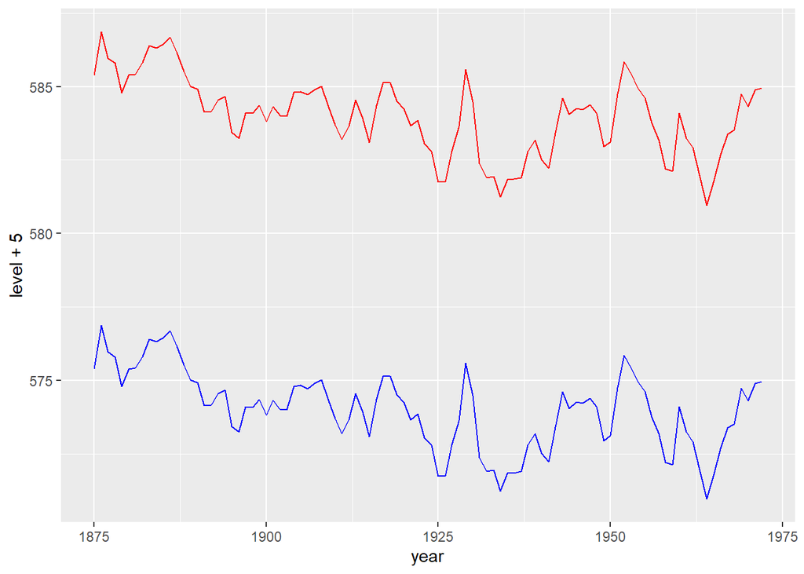

```r
library(ggplot2)
library(dplyr)
library(gridExtra)
library(mgcv)
library(MASS)
library(directlabels)
library(wesanderson)

huron <- data.frame(year = 1875:1972, level = as.numeric(LakeHuron))
ggplot(huron, aes(year)) +
geom_line(aes(y = level + 5), colour = "red") +
geom_line(aes(y = level - 5), colour = "blue")
```

- That doesn’t work in ggplot because there’s no way to add a legend manually. Instead, give the lines informative labels:

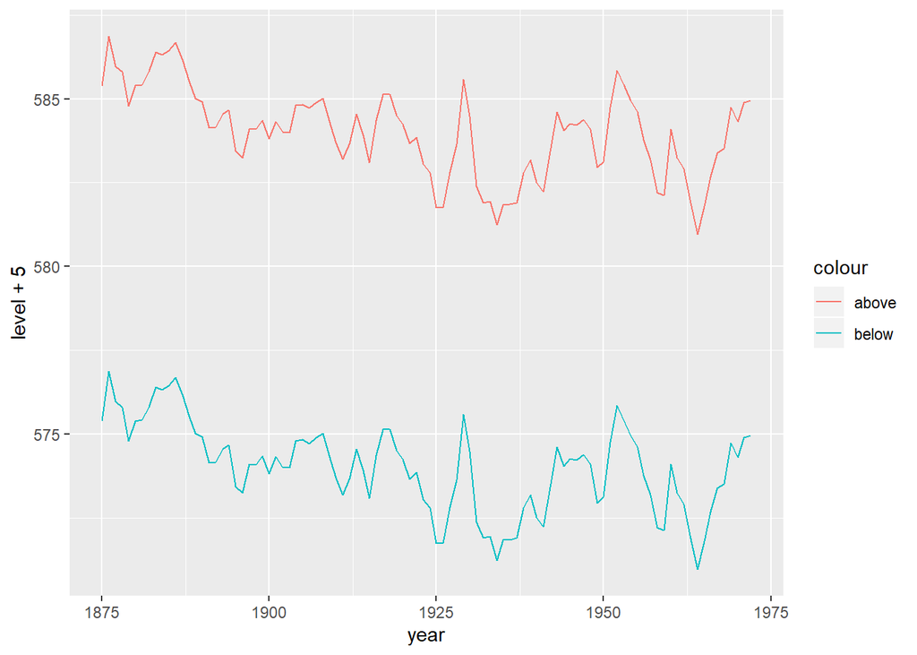

```r
library(ggplot2)
library(dplyr)
library(gridExtra)
library(mgcv)
library(MASS)
library(directlabels)
library(wesanderson)

ggplot(huron, aes(year)) +
geom_line(aes(y = level + 5, colour = "above")) +
geom_line(aes(y = level - 5, colour = "below"))
```

- And then tell the scale how to map labels to colours:

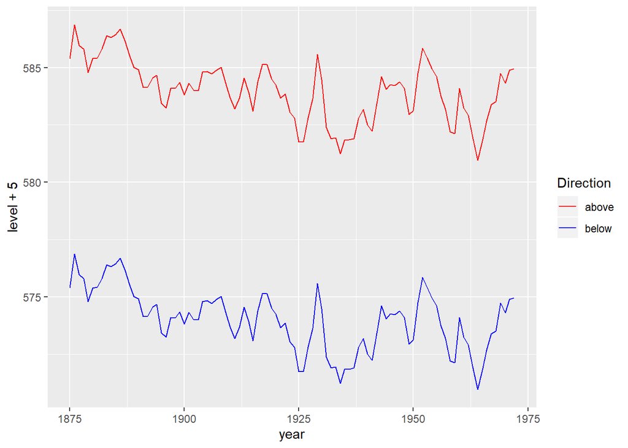

```r
library(ggplot2)
library(dplyr)
library(gridExtra)
library(mgcv)
library(MASS)
library(directlabels)
library(wesanderson)

ggplot(huron, aes(year)) +
geom_line(aes(y = level + 5, colour = "above")) +
geom_line(aes(y = level - 5, colour = "below")) +
scale_colour_manual("Direction",
values = c("above" = "red", "below" = "blue")
)
```

## The Identity Scale

- The identity scale is used when your data is already scaled, when the data and aesthetic spaces are the same. The code below shows an example where the identity scale is useful. luv colours contains the locations of all R’s built-in colours in the LUV colour space (the space that HCL is based on). A legend is unnecessary, because the point colour represents itself: the data and aesthetic spaces are the same.

```r
library(ggplot2)
library(dplyr)
library(gridExtra)
library(mgcv)
library(MASS)
library(directlabels)
library(wesanderson)

head(luv_colours)
```

```
         L             u         v           col
1 9341.570 -3.370649e-12    0.0000         white
2 9100.962 -4.749170e+02 -635.3502     aliceblue
3 8809.518  1.008865e+03 1668.0042  antiquewhite
4 8935.225  1.065698e+03 1674.5948 antiquewhite1
5 8452.499  1.014911e+03 1609.5923 antiquewhite2
6 7498.378  9.029892e+02 1401.7026 antiquewhite3
```

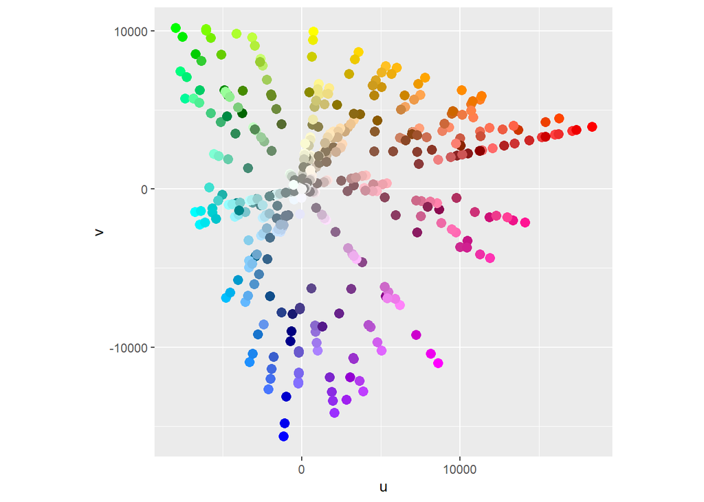

```r
ggplot(luv_colours, aes(u, v)) +
geom_point(aes(colour = col), size = 3) +
scale_color_identity() +
coord_equal()
```

## References

- Azzalini A, Bowman AW (1990) A look at some data on the old faithful geyser. Appl Stat 39:357–65
- Lumley T (2013) dichromat: color schemes for dichromats. R package version 2.0-0. https://CRAN.R-project.org/package=dichromat
- Zeileis A, Kurt H, Paul M (2008) Escaping RGBland: selecting colors for statistical graphics. Comput Stat Data Anal. http://statmath.wu-wien. ac.at/∼zeileis/papers/Zeileis+Hornik+Murrell-2008.pdf